# Reto en clase. Clases 23 y 24

Series de tiempo univariadas, 3009297, 2026-II

Autor/a

Sarah Catalina Criollo García y Sara Jurado Giraldo

# Caso A: CO₂ de Mauna Loa

Trabajamos en este caso A con los datos del observatorio de Mauna Loa, en Hawái, los datos proporcinados se encargan de mide desde 1958 la concentración de dióxido de carbono en el aire, y su registro es la referencia mundial para seguir el aumento de este gas.

```
            n entrenamiento    validacion
          165           153            12
```

De los datos que obtuvimos tenemos que n=165 meses en total, los primeros 153 se usan para identificar y estimar el modelo, y los últimos doce, de octubre de 2024 a septiembre de 2025, para validarlo. Adicionalmente vemos que la serie tiene dos rasgos claros. 1. Tenemos una tendencia creciente ya que se emite más carbono del que los océanos y la vegetación alcanzan a absorber. 2. Tenemmos un ciclo anual porque las plantas del hemisferio norte capturan CO<sub>2</sub> durante el verano boreal y lo liberan en el invierno.

El objetivo de la realización de este caso es construir un modelo SARIMA que recoja los rasgos de la serie, compararlo con métodos sencillos y pronosticar con intervalos del 95 % los doce meses de octubre de 2025 a septiembre de 2026.

## A1. Mirar la serie

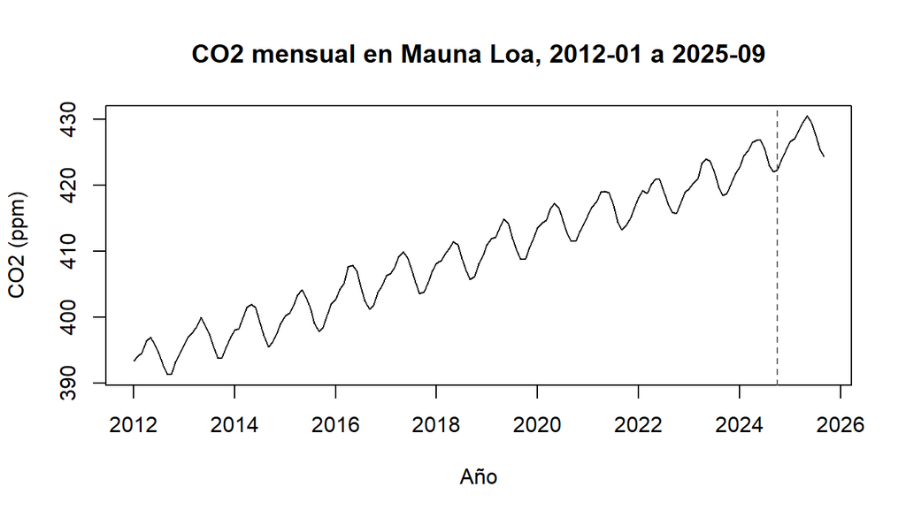

```
    1     2     3     4     5     6     7     8     9    10    11    12
 0.26  0.89  1.44  2.77  3.28  2.48  0.38 -1.91 -3.47 -3.39 -1.98 -0.73
```

```
           2012  2013   2014   2015   2016   2017   2018   2019   2020   2021
nivel    394.10 396.7 398.80 401.00 404.40 406.80 408.70 411.60 414.20 416.40
amplitud   5.66   6.3   6.42   6.33   6.67   6.32   5.73   6.12   5.79   5.83
           2022  2023   2024
nivel    418.50 421.1 424.60
amplitud   5.23   5.5   4.88
```

```
   crec_medio   crec_ultimo    oscilacion cor_amp_nivel
    2.5642484     3.0200000     6.7464343    -0.6999171
```

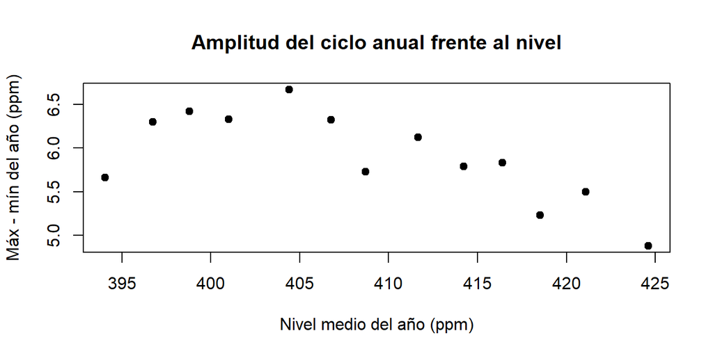

**Respuesta.** Con base a las pruebas vemos que la serie sube en promedio 2,56 ppm por año (media de las diferencias $\nabla_{12}Z_t$) y en el último año, de octubre de 2024 a septiembre de 2025, subió 3,02 ppm, más rápido que el promedio.

El ciclo anual tiene el máximo en mayo y el mínimo en septiembre, y tambien podemos observar que presenta una oscilación entre los dos, una vez quitada la tendencia con una media móvil 2×12, es de 6,75 ppm.

La amplitud anual que evidenciamos va de 4,88 a 6,67 ppm y no crece con el nivel (la correlación entre amplitud y nivel es -0,70), de modo que el ciclo es aditivo: la vegetación toma y devuelve aproximadamente la misma cantidad de CO<sub>2</sub> cada año.

## A2. ¿Hace falta transformar?

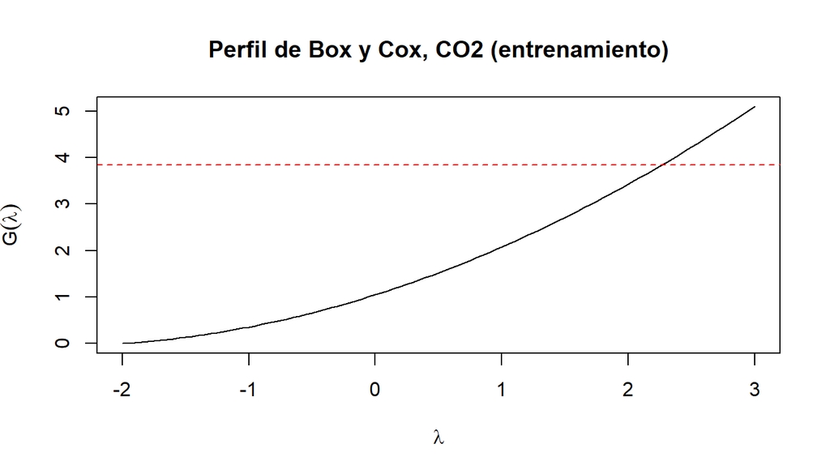

```
   lambda_hat       lim_inf       lim_sup            G1          G0.5
    -2.000000     -2.000000      2.250000      2.076803      1.521984
           G0 max_sobre_min
     1.049502      1.091088
```

**Respuesta.** La prueba de box-cox nos permite evidenciar que el perfil es casi plano, donde $\lambda$ es de −2 a 3 desde el borde inferior de la malla (-2,00) hasta 2,25, y se tienen a $G(\lambda) < \chi^2_{1;0,95} = 3,84$, y en particular $G(1) =$ 2,08, $G(0,5) =$ 1,52 y $G(0) =$ 1,05, podemos ver que todos son compatibles con los datos; incluso el mínimo cae en el borde de la malla($\lambda$). El perfil de este caso no distingue porque el nivel varía muy poco en términos relativos: el máximo del entrenamiento es solo 9,1 % mayor que el mínimo (cociente 1,091), y en un rango tan estrecho cualquier potencia $Z^\lambda$ es casi una función lineal de $Z$. Además vemos que la amplitud del ciclo no crece con el nivel (A1), con toda la informacion recolectada vemos que **no transformamos** ($\lambda = 1$), lo que deja el modelo y el pronóstico en ppm sin retransformar.

## A3. ¿Cuántas diferencias?

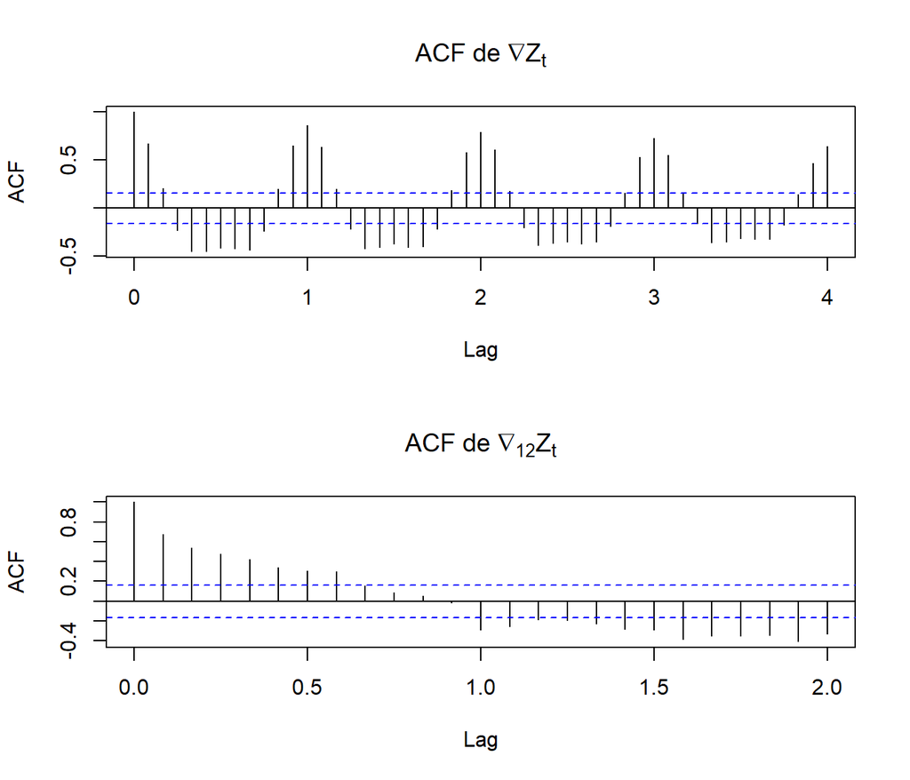

```
$acf_nabla_12_24_36
[1] 0.861 0.790 0.726

$acf_nabla12_1a6
[1] 0.671 0.534 0.474 0.422 0.341 0.307
```

**Respuesta.** Con los resultados obtenidos vemos que $\nabla Z_t$ tiene las autocorrelaciones en los rezagos 12, 24 y 36 son 0,861, 0,790 y 0,726, podemos evidenciar que son grandes y tienden a decaen muy despacio, que es la huella de una componente estacional no estacionaria, por lo que tomamos **D = 1**.

Por otro lado $\nabla_{12} Z_t$ obtiene las autocorrelaciones de los rezagos 1 a 6 son 0,671; 0,534; 0,474; 0,422; 0,341; 0,307, donde vemos que todas son positivas y con un decaimiento lento y casi lineal, podemos evidencia la huella de una raíz unitaria regular ( donde la tendencia que sube unas 2,6 ppm por año), así que tomamos también **d = 1**. Con una sola de las dos diferencias queda una no estacionariedad, de modo que $W_t = \nabla\nabla_{12} Z_t$ es la serie estacionaria de la que parte la identificación; con $d + D = 2$ el modelo no lleva constante.

## Bono opcional. Prueba HEGY

```
    HEGY test for unit roots

data:  ztr

        statistic p-value
t_1        0.7528  0.9918
t_2        -3.468  0.0073 **
F_3:4     13.3985   4e-04 ***
F_5:6       9.773  0.0051 **
F_7:8     13.4973   4e-04 ***
F_9:10    18.0515       0 ***
F_11:12    9.3008  0.0071 **
F_2:12    29.8866       0 ***
F_1:12    27.8701       0 ***
---
Signif. codes: 0 '***' 0.001 '**' 0.01 '*' 0.05 '.' 0.1 ' ' 1

Deterministic terms: constant + seasonal dummies
Lag selection criterion and order: BIC, 0
P-values: based on response surface regressions
```

```
    HEGY test for unit roots

data:  ztr

        statistic p-value
t_1       -2.6253  0.1893
t_2       -3.5761  0.0059 **
F_3:4     15.9868       0 ***
F_5:6      10.817  0.0027 **
F_7:8     15.1118   1e-04 ***
F_9:10     19.227       0 ***
F_11:12    9.8488  0.0052 **
F_2:12     32.033       0 ***
F_1:12    29.3875       0 ***
---
Signif. codes: 0 '***' 0.001 '**' 0.01 '*' 0.05 '.' 0.1 ' ' 1

Deterministic terms: constant + trend + seasonal dummies
Lag selection criterion and order: BIC, 0
P-values: based on response surface regressions
```

**Respuesta.** de la *Prueba de $t_1$ (frecuencia cero).* podemos concluir que:

1. H<sub>0</sub>: $\pi_1 = 0$, hay una raíz unitaria en $B = 1$ (raíz regular); H<sub>1</sub>: $\pi_1 < 0$, no la hay.
2. $t_1 = \hat\pi_1/\text{ee}(\hat\pi_1)$ en la regresión HEGY, que bajo H<sub>0</sub> no sigue una $t$ de Student sino una distribución de tipo Dickey y Fuller, cuyos valores p `hegy.test` obtiene por superficies de respuesta.
3. Se rechaza si el valor p es menor que 0,05 (cola izquierda).
4. $t_1 =$ -2,625 con valor p 0,189; sin tendencia, $t_1 =$ 0,753 con valor p 0,992.
5. El CO<sub>2</sub> tiene una raíz unitaria regular: la tendencia es estocástica y hace falta la diferencia $\nabla$ ($d = 1$), como dijo A3.

En cambio, $t_2$ es frecuencia semestral donde todos los F de los pares de frecuencias estacionales son, $F_{3:4}$ a $F_{11:12}$, se rechazan en las dos versiones (el mayor valor p es 0,0073), y el conjunto $F_{2:12}$ vale 29,89 sin tendencia y 32,03 con tendencia. Por lo tanto no hay raíces unitarias estacionales ya que el ciclo anual del CO<sub>2</sub> es determinístico, además, se repite cada año con la misma forma y no acumula choques. Aun así, el modelo de SARIMA con D = 1 es una aproximación razonable porque, si $\Theta$ está cerca de 1, el factor $(1 - \Theta B^{12})$ casi cancela la diferencia $\nabla_{12}$, lo que equivale a un modelo con dummies estacionales fijas; además, quita el patrón sin tener que estimar doce efectos, y en A5 y A7 $\hat\Theta$ resulta cercano a 1.

## A4. Identificar el modelo

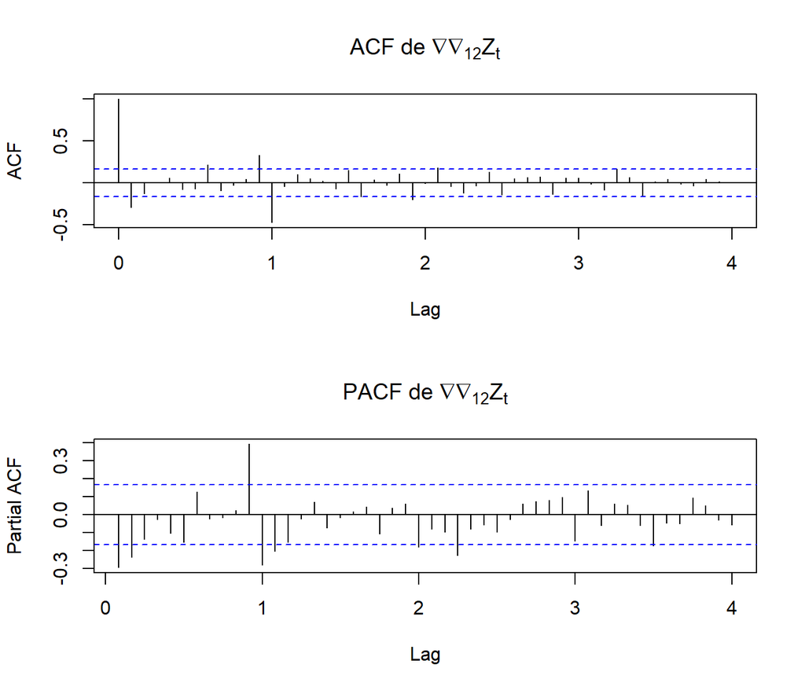

```
   rezago   acf  pacf
1       1 -0.29 -0.29
2       2 -0.13 -0.24
7       7  0.21  0.13
11     11  0.33  0.39
12     12 -0.48 -0.28
13     13 -0.04 -0.20
23     23 -0.20  0.06
24     24 -0.01 -0.18
25     25  0.18 -0.08
27     27 -0.12 -0.22
```

```
[1] 0.1690309
```

```
             modelo      BIC      AIC     dBIC
6  (0,1,1)(0,1,1)12 145.4775 136.6526 0.000000
10 (0,1,2)(0,1,1)12 148.1385 136.3719 2.661015
18 (1,1,1)(0,1,1)12 148.2782 136.5116 2.800688
8  (0,1,1)(1,1,1)12 150.3236 138.5570 4.846074
26 (2,1,0)(0,1,1)12 152.4301 140.6635 6.952624
12 (0,1,2)(1,1,1)12 153.0124 138.3042 7.534883
```

**Respuesta.** La banda que obtuvimos fue de ±0,169 ($2/\sqrt{n_W}$), e e grafico podemos evidenciar que en la parte regular la ACF de $W_t$ tiene un solo pico, $r_1 =$ -0,29, y se corta después, mientras que el comporatmiento de la PACF decae ($-0,29$, $-0,24$, …), lo que apunta a un MA(1) regular.

En la parte estacional que posee la ACF tiene $r_{12} =$ -0,48 y $r_{24} =$ -0,01, es decir, se corta después del primer rezago estacional, mientras que la PACF en 12 y 24 (-0,28 y -0,18) decae, lo que apunta a un MA(1) estacional; donde los picos en los rezagos 11, 13, 23 y 25 son los satélites alrededor de 12 y 24 que produce el producto $(1-\theta B)(1-\Theta B^{12})$, y el de 7 (0,21) es aislado y no se repite.  
Además observamos que se tiene el menor BIC (145,48). El segundo es (0,1,2)(0,1,1)12 con 2,66 unidades más de BIC: donde agregamos un parámetro que la ACF no pide (solo $r_1$ sale de la banda en la parte regular).

## A5. Estimar, validar y buscar atípicos

```
Call:
arima(x = ztr, order = orden_A$order, seasonal = list(order = orden_A$seasonal,
    period = 12), method = "ML")

Coefficients:
          ma1     sma1
      -0.4858  -0.8161
s.e.   0.0862   0.0868

sigma^2 estimated as 0.1353:  log likelihood = -65.33,  aic = 136.65
```

```
               ma1   sma1
estimador_R -0.486 -0.816
ee           0.086  0.087
t           -5.634 -9.402
```

```
    Box-Ljung test

data:  resA
X-squared = 19.346, df = 22, p-value = 0.6239
```

```
[1] 33.92444
```

```
    Shapiro-Wilk normality test

data:  resA[-(1:13)]
W = 0.99183, p-value = 0.5978
```

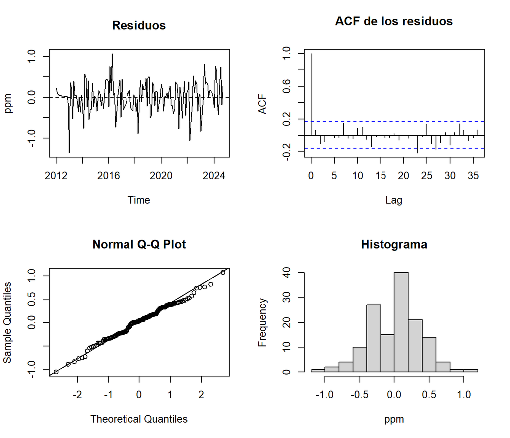

```
  IO   AO   LS   TC
2.67 2.83 3.15 3.31
```

```
[1] T  IO AO LS TC
<0 rows> (or 0-length row.names)
```

```
               estimador      t     BIC
(1,1,1)(0,1,1)     0.225  1.516 148.278
(0,1,2)(0,1,1)    -0.122 -1.530 148.139
(0,1,1)(1,1,1)    -0.038 -0.311 150.324
(0,1,1)(0,1,2)     0.033  0.321 150.316
```

```
[1] 0.646 0.986
```

```
Theta_full
     0.907      0.675      1.138
```

**Respuesta.** El modelo estimado, con la convención fue ($\theta_1 = -$ma1, $\Theta_1 = -$sma1), es
$$\nabla\nabla_{12} Z_t = (1 - 0,486\,B)(1 - 0,816\,B^{12})\,a_t,\qquad \hat\sigma_a^2 = 0,1353,$$
con $t(\hat\theta_1) =$ 5,63 y $t(\hat\Theta_1) =$ 9,40, observamos que los dos son muy significativos.

De la *Prueba de Ljung y Box* obtuvimos lo siguiente:

1. H<sub>0</sub>: $\rho_1 = \dots = \rho_{24} = 0$ en los errores, H<sub>1</sub>: algún $\rho_k \neq 0$.
2. $Q^* = n(n+2)\sum_{k=1}^{24} r_k^2/(n-k) \sim \chi^2_{K-m} = \chi^2_{22}$, con $m = 2$ parámetros ARMA.
3. Se rechaza si $Q^* > \chi^2_{22;0,95} =$ 33,92.
4. $Q^* =$ 19,35 (valor p 0,624).
5. No se rechaza H<sub>0</sub>.
6. Los residuos no muestran autocorrelación hasta dos años: el modelo recoge la dinámica regular y estacional del CO<sub>2</sub>.

La prueba de Shapiro y Wilk da W = 0,992 nos arrojo un valor p 0,598 y el QQ es recto, así que la normalidad que usan los intervalos de pronóstico es razonable. En la búsqueda de valores atípicos el mayor $|\lambda_j(T)|$ es de 3,31, por debajo de 3,5, de modo que no se declara ningún valor atípico, como dice el enunciado del reto (solo estabamos rectificando).

Al realizar el sobreajuste vimos que ninguno de los cuatro parámetros añadidos es significativo (el mayor $|t|$ es 1,53) ya que todos suben el BIC. El intervalo del 95 % para $\Theta$ es [0,646; 0,986]: este no contiene el 1, pero su límite superior está muy cerca, lo que nos dice que hay un patrón estacional que cambia muy poco de un año a otro, tambien podemos decir que es casi determinístico; al reestimar con los 165 meses (A7) $\hat\Theta =$ 0,907 y el intervalo [0,675; 1,138] ya contiene el 1.

## A6. ¿Le gana el SARIMA a las referencias?

```
                      RMSE  MAPE  MASE
SARIMA               0.225 0.049 0.082
Ingenuo estacional   3.066 0.708 1.196
Holt-Winters aditivo 0.282 0.056 0.095
```

```
[1] 2.525461
```

```
[1] 12
```

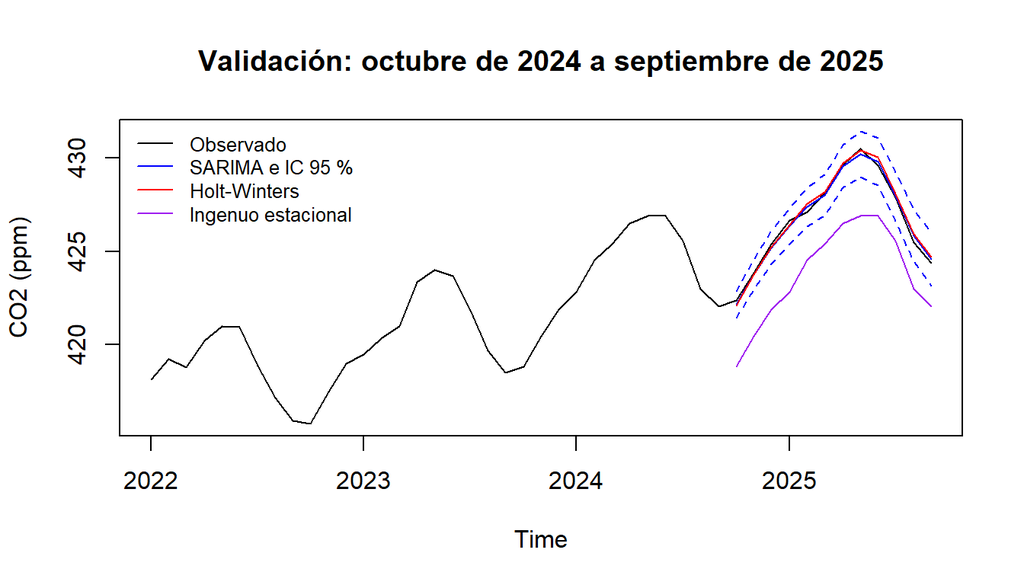

**Respuesta.** Observamos que en los doce meses de validación el modelo SARIMA tiene RMSE = 0,225 ppm, MAPE = 0,049 % y MASE = 0,082; Holt-Winters queda cerca con 0,282, 0,056 % y 0,095, y el ingenuo estacional queda muy atrás con 3,066, 0,708 % y 1,196.

El MASE divide el error absoluto medio del método entre el del ingenuo estacional dentro del entrenamiento, 2,525 ppm, así que un MASE de 0,082 quiere decir que el SARIMA tiene un error cerca del 8 % de lo que se equivocaba el ingenuo, y un MASE mayor que 1 indica que el método es peor que esa referencia. Vemos que el ingenuo estacional pierde tanto porque repite el valor de hace doce meses y no ve la tendencia ya que llega siempre unas 2,6 a 3,0 ppm por debajo, que es justo el crecimiento anual. Los 12 de los 12 valores observados caen dentro del intervalo del 95 % del SARIMA.

## A7. El pronóstico del tablero

```
Call:
arima(x = z, order = orden_A$order, seasonal = list(order = orden_A$seasonal,
    period = 12), method = "ML")

Coefficients:
          ma1     sma1
      -0.4965  -0.9067
s.e.   0.0803   0.1181

sigma^2 estimated as 0.1228:  log likelihood = -66.36,  aic = 138.73
```

Pronóstico del CO2 (ppm), octubre de 2025 a septiembre de 2026

| fecha | pronostico | li95 | ls95 | ancho |
| --- | --- | --- | --- | --- |
| 2025-10 | 424.631 | 423.939 | 425.323 | 1.384 |
| 2025-11 | 426.242 | 425.468 | 427.017 | 1.550 |
| 2025-12 | 427.702 | 426.853 | 428.552 | 1.699 |
| 2026-01 | 428.900 | 427.982 | 429.818 | 1.836 |
| 2026-02 | 429.770 | 428.788 | 430.751 | 1.963 |
| 2026-03 | 430.489 | 429.447 | 431.531 | 2.083 |
| 2026-04 | 432.051 | 430.952 | 433.149 | 2.196 |
| 2026-05 | 432.760 | 431.608 | 433.912 | 2.304 |
| 2026-06 | 432.175 | 430.972 | 433.379 | 2.407 |
| 2026-07 | 430.334 | 429.081 | 431.587 | 2.505 |
| 2026-08 | 428.217 | 426.917 | 429.517 | 2.600 |
| 2026-09 | 426.925 | 425.579 | 428.270 | 2.692 |

```
           pareja   fecha pronostico
1  criollo-jurado 2025-10    424.631
2  criollo-jurado 2025-11    426.242
3  criollo-jurado 2025-12    427.702
4  criollo-jurado 2026-01    428.900
5  criollo-jurado 2026-02    429.770
6  criollo-jurado 2026-03    430.489
7  criollo-jurado 2026-04    432.051
8  criollo-jurado 2026-05    432.760
9  criollo-jurado 2026-06    432.175
10 criollo-jurado 2026-07    430.334
11 criollo-jurado 2026-08    428.217
12 criollo-jurado 2026-09    426.925
```

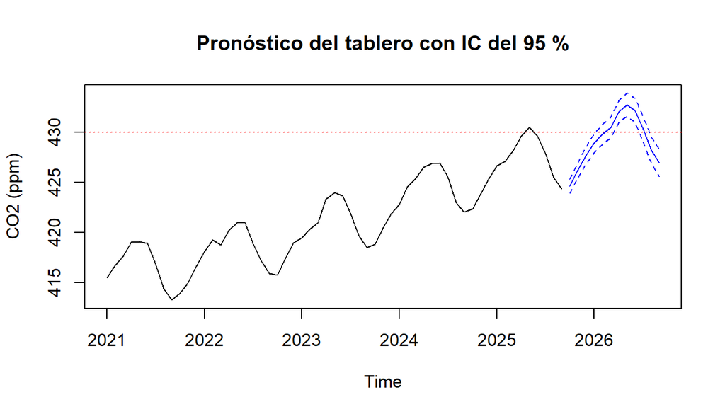

**Respuesta.** Para realizar el tablero usamos el SARIMA(0,1,1)(0,1,1)<sub>12</sub> reestimado con los 165 meses, porque en A5 las pruebas de validación nos mostro que las pasó todas sin valores atípicos ni parámetros sobrantes, y en A6 obtuvimos el menor RMSE, MAPE y MASE, con 12 de 12 valores dentro de su intervalo; lo reestimamos con los datos completos aprovecha el último año, que creció más rápido.

- El pronóstico de mayo de 2026 nos arrojo que tenemos el máximo estacional, es 432,760 ppm con intervalo del 95 % [431,608; 433,912], y el primer mes en que el pronóstico supera 430 ppm es 2026-03.
- El intervalo de septiembre de 2026 (ancho 2,692 ppm) es más ancho que el de octubre de 2025 (1,384 ppm) porque la varianza del error de pronóstico es de $\sigma_a^2\sum_{j=0}^{h-1}\psi_j^2$, este crece con el horizonte $h$: a doce meses se acumulan los choques de los once meses intermedios, que el modelo integrado no deja que se disipen.
- Al realizar el supuesto que podría fallar es que el crecimiento anual se mantenga como en la muestra: ya que se puede reducir la absorción de las plantas y sube el crecimiento, como en 2016 y 2024 o un cambio en las emisiones rompería la homogeneidad de $\{a_t\}$ y dejaría el pronóstico por debajo o por encima del observado.

**Apuesta del equipo:**. En la historia de la serie pudimos observar que el primer promedio mensual esta por encima de 430 ppm fue mayo de 2025 (430,51 ppm), pero después vimos que la serie bajó con el ciclo; en el año del tablero el modelo dice que el primer cruce es 2026-03, con febrero de 2026 en 429,77 ppm, muy cerca del umbral. Si el crecimiento de 3,02 ppm del último año se repite, febrero de 2026 quedaría en unas 430,11 ppm, por encima de 430, así que una apuesta razonable es febrero de 2026 y la del modelo es marzo de 2026.

# Caso B: viajeros del Reino Unido a Australia

# Declaración de uso de asistentes de inteligencia artificial

# Información de la sesión